# MSDM5003_hw7_ChengWingKit

```python
import yfinance as yf
import numpy as np
from random import seed
import matplotlib.pyplot as plt

seed(5003)

def update_state(mu, b):
    return (2 * mu + b) % states

# download HSI data
df = yf.Ticker('^HSI').history(period='max')
Pt = df.Close.dropna()
T = len(Pt)

# define beta and generate transaction price series
beta = 0.5
Ptt = Pt.shift(1)+beta*(Pt-Pt.shift(1))

# initialization
M = 3
states = 2**M
Nstrategy = 2**states
mu = np.zeros(T, dtype='int') # input state
Ws = np.zeros((Nstrategy,T))
Ws[:,0] = np.ones(Nstrategy)*5*Pt.iloc[0] # virtual wealth of each strategy
Ks = np.zeros((Nstrategy,T)) # virtual positions of each strategy

# generate decision matrix
s = [f'{i:08b}' for i in range(Nstrategy)]
decision_list = [[2*int(c)-1 for c in s[j]][::-1] for j in range(Nstrategy)]
dm = np.array(decision_list) # 2**(2**M) x 2**M decision matrix, i.e. 256 x 8 for M=3

# Calculation of the strategy
t = 1
bt = (Pt>Pt.shift(1))*1
while t < T:
    mu[t] = update_state(mu[t-1], bt[t])
    decisions = dm[:, mu[t]]
    Ks[:,t] = np.maximum(-Ws[:,t-1]/Pt[t-1], np.minimum(Ws[:,t-1]/Pt[t-1], Ks[:,t-1]+decisions))
    Ws[:,t] = Ws[:,t-1]+Ks[:,t-1]*(Pt[t]-Pt[t-1])
    t += 1
```

```python
# Simulation of the agents
N = 101
Wi = np.zeros((N, T))
Wi[:,0] = np.ones(N)*5*Pt.iloc[0]
Ki = np.zeros((N, T))
Ns = 2 # number of strategy per agent

agent_strategy = np.random.randint(0, Nstrategy, (N, Ns)) # Agents' strategy array

t = 1
while t < T:
    if t==1:
        seq = np.random.randint(0, 2, N)
    else:
        vw = np.array([[Ws[i[0],t-1], Ws[i[1],t-1]] for i in agent_strategy])
        seq = np.zeros(N, int)
        for i in range(N):
            if vw[i,1] > vw[i,0]:
                seq[i] = 1
            elif vw[i,1] == vw[i,0]:
                seq[i] = np.random.randint(0, 2)
    choice = [agent_strategy[i,seq[i]] for i in range(N)]
    decisions = [dm[i,mu[t]] for i in choice]
    Ki[:,t] = np.maximum(-Wi[:,t-1]/Pt[t-1], np.minimum(Wi[:,t-1]/Pt[t-1], Ki[:,t-1]+decisions))
    Wi[:,t] = Wi[:,t-1]+Ki[:,t-1]*(Pt[t]-Pt[t-1])
    t += 1
```

```python
# (12)
print(f'Best virtual wealth among all stratgies = {max(Ws[:,-1]/Ws[:,0]):.2f} times the initial wealth')
print(f'Average virtual wealth among all stratgies = {(Ws[:,-1]/Ws[:,0]).mean():.2f} times the initial wealth')
print(f'Worst virtual wealth among all stratgies = {min(Ws[:,-1]/Ws[:,0]):.2f} times the initial wealth')

print(f'Best real wealth among all agents = {max(Wi[:,-1]/Wi[:,0]):.2f} times the initial wealth')
print(f'Average real wealth among all agents = {(Wi[:,-1]/Wi[:,0]).mean():.2f} times the initial wealth')
print(f'Worst real wealth among all agents = {min(Wi[:,-1]/Wi[:,0]):.2f} times the initial wealth')
```

```
Best virtual wealth among all stratgies = 23.02 times the initial wealth
Average virtual wealth among all stratgies = 2.88 times the initial wealth
Worst virtual wealth among all stratgies = 0.00 times the initial wealth
Best real wealth among all agents = 22.77 times the initial wealth
Average real wealth among all agents = 3.83 times the initial wealth
Worst real wealth among all agents = 0.00 times the initial wealth
```

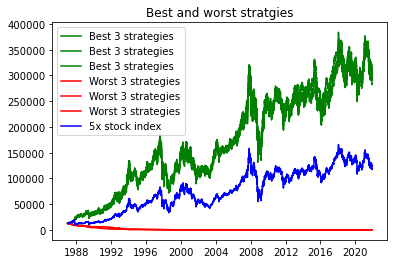

```python
# (13)
plt.figure()
best3s = Ws[:,-1].argsort()[-3:][::-1]
worst3s = Ws[:,-1].argsort()[:3]
plt.plot(Pt.index, Ws[best3s,:].T, 'g-', label='Best 3 strategies')
plt.plot(Pt.index, Ws[worst3s,:].T, 'r-', label='Worst 3 strategies')
plt.plot(Pt*5, 'b-', label='5x stock index')
plt.title('Best and worst stratgies')
plt.legend()
plt.show()
```

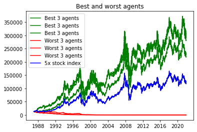

```python
# (14)
plt.figure()
best3i = Wi[:,-1].argsort()[-3:][::-1]
worst3i = Wi[:,-1].argsort()[:3]
plt.plot(Pt.index, Wi[best3i,:].T, 'g-', label='Best 3 agents')
plt.plot(Pt.index, Wi[worst3i,:].T, 'r-', label='Worst 3 agents')
plt.plot(Pt*5, 'b-', label='5x stock index')
plt.title('Best and worst agents')
plt.legend()
plt.show()
```

# Observation regarding strategies

```python
print(f'Best 3 strategies:\n{dm[best3s,:]}')
```

```
Best 3 strategies:
[[ 1  1 -1  1  1 -1 -1  1]
 [ 1  1 -1  1 -1 -1  1  1]
 [ 1  1 -1 -1  1 -1  1  1]]
```

Observations:  
Among the 3 best strategies, we can observe that 5 out of 8 decisions are the same, including (0 indicate price drop and 1 indicate price rise):  
000(0) -> buy  
001(1) -> buy  
010(2) -> sell  
101(5) -> sell  
111(7) -> buy  
Other strategies having the above 5 decisions are also considered:

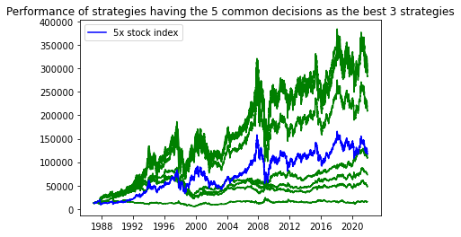

```python
b3_base = 128+2+1
test_b3 = []
for i in [0,1]:
    for j in [0,1]:
        for k in [0,1]:
            test_b3.append(b3_base+i*8+j*16+k*64)
plt.plot(Pt.index, Ws[test_b3,:].T, 'g-')
plt.plot(Pt*5, 'b-', label='5x stock index')
plt.title('Performance of strategies having the 5 common decisions as the best 3 strategies')
plt.legend()
plt.show()
```

Not all of the above perform better than the market index. Among those that are beating the market, buying decisions is dominated in the strategy.  
Other winning strategies are considered and it is observed that all are having more buying decisions than selling decisions. We can conclude that having more buying decisions than selling decisions is a necessary but not sufficient condition of being a winning strategy as indicated in the figures below.

```
There are 32 winning strategy, with id=[143 151 155 167 171 174 175 179 182 185 186 187 190 191 203 211 217 218
 219 227 230 231 235 237 238 239 242 243 249 250 251 254]
```

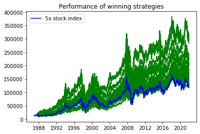

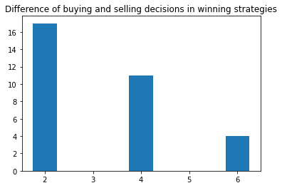

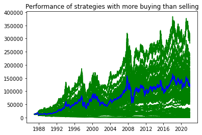

```python
winning_s = np.where(Ws[:,-1]>5*Pt[-1])[0]
winning = dm[Ws[:,-1]>5*Pt[-1],:]
print(f'There are {len(winning_s)} winning strategy, with id={winning_s}')

plt.plot(Pt.index, Ws[Ws[:,-1]>5*Pt[-1],:].T, 'g-')
plt.plot(Pt.index, 5*Pt, 'b-', label='5x stock index')
plt.title('Performance of winning strategies')
plt.legend()
plt.figure()
labels, counts = np.unique(winning.sum(axis=1), return_counts=True)
plt.bar(labels, counts, align='center', width=0.5)
plt.title('Difference of buying and selling decisions in winning strategies')
plt.figure()
plt.plot(Pt.index, Ws[dm.sum(axis=1)>0,:].T,'g-')
plt.plot(Pt.index, 5*Pt, 'b-', label='5x stock index')
plt.title('Performance of strategies with more buying than selling')
plt.show()
```

```python
print(f'Worst 3 strategies:\n{dm[worst3s,:]}')
```

```
Worst 3 strategies:
[[-1 -1  1 -1  1 -1  1 -1]
 [-1 -1  1 -1  1 -1 -1 -1]
 [ 1 -1  1 -1  1 -1 -1 -1]]
```

For the worst 3 strategies, 6 out of 8 decisions are the same, including:  
001(1) -> sell  
010(2) -> buy  
011(3) -> sell  
100(4) -> buy  
101(5) -> sell  
111(7) -> sell  
Unlike the winning strategies, these are dominated by selling decisions.  
Other strategies dominated by selling decisions are considered:

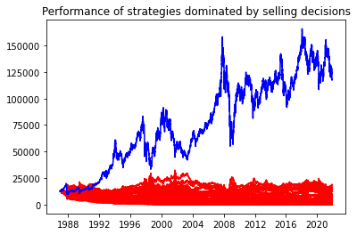

```python
plt.plot(Pt.index, Ws[dm.sum(axis=1)<0,:].T,'r-')
plt.plot(Pt.index, 5*Pt, 'b-', label='5x stock index')
plt.title('Performance of strategies dominated by selling decisions')
plt.show()
```

All strategies dominated by selling decisions turn out to be losing. We can conclude that having more selling decisions than buying decisions is a sufficient condition of being a losing strategy.

# Observation regarding agents

The performance of the strategies of each winning agent are plotted below.

```
There are 16 winning agents, with id=[ 0  3 23 25 30 33 37 41 44 52 59 64 73 74 91 97]
```

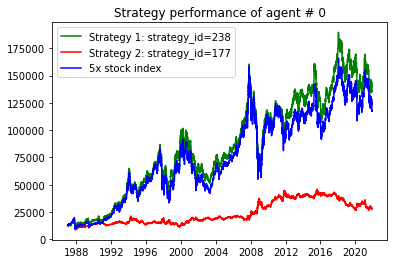

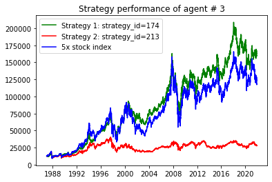

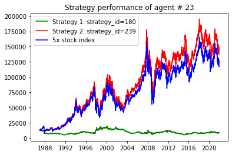

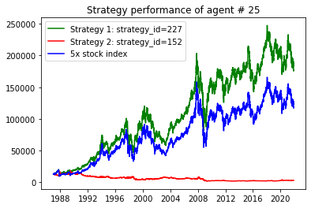

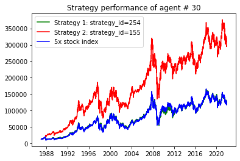

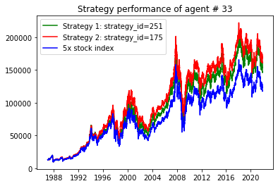

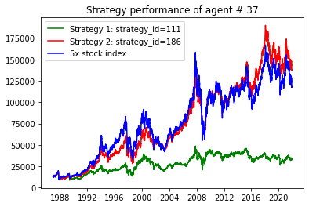

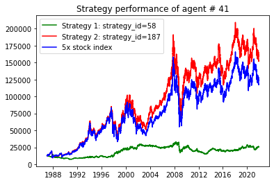

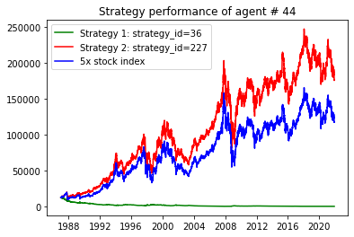

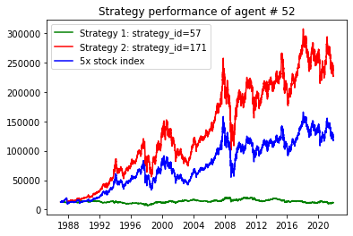

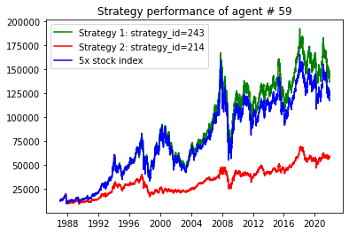

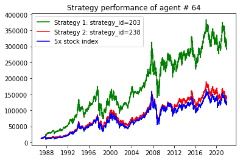

[4 more figures not shown]

```python
winning_agents = np.where(Wi[:,-1]>5*Pt[-1])[0]
print(f'There are {len(winning_agents)} winning agents, with id={winning_agents}')
for i in winning_agents:
    plt.figure()
    plt.plot(Pt.index, Ws[agent_strategy[i,0],:], 'g-', label=f'Strategy 1: strategy_id={agent_strategy[i,0]}')
    plt.plot(Pt.index, Ws[agent_strategy[i,1],:], 'r-', label=f'Strategy 2: strategy_id={agent_strategy[i,1]}')
    plt.plot(Pt.index, 5*Pt, 'b-', label='5x stock index')
    plt.legend()
    plt.title(f'Strategy performance of agent # {i}')
plt.show()
```

Clearly, each winning agent has at least one winning strategy within their strategy pool. A custom agent with the best 2 strategies are tested below.

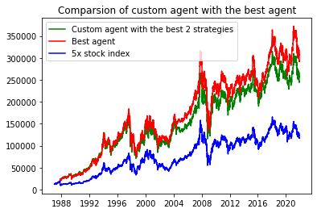

```python
# Simulation an agent having best 2 best strategies
Wib = np.ones(T)*5*Pt.iloc[0]
Kib = np.zeros(T)

Sb = best3s[:2]

t = 1
while t < T:
    if t==1:
        seq = np.random.randint(0, 2)
    else:
        vw = np.array([Ws[Sb[0],t-1], Ws[Sb[1],t-1]] )
        seq = 0
        if vw[1] > vw[0]:
            seq = 1
        elif vw[1] == vw[0]:
            seq = np.random.randint(0, 2)
    choice = Sb[seq]
    decisions = dm[choice,mu[t]]
    Kib[t] = np.maximum(-Wib[t-1]/Pt[t-1], np.minimum(Wib[t-1]/Pt[t-1], Kib[t-1]+decisions))
    Wib[t] = Wib[t-1]+Kib[t-1]*(Pt[t]-Pt[t-1])
    t += 1

plt.plot(Pt.index, Wib,'g-', label='Custom agent with the best 2 strategies')
plt.plot(Pt.index, Wi[best3i[0],:],'r-', label='Best agent')
plt.plot(Pt.index, 5*Pt, 'b-', label='5x stock index')
plt.title('Comparsion of custom agent with the best agent')
plt.legend()
plt.show()
```

Interestingly, the custom agent did not perform better than the best agent.

## In summary, it is observed that:

## 1. Having more buying decisions than selling decisions is a necessary but not sufficient condition of being a winning strategy.

## 2. Having more selling decisions than buying decisions is a sufficient but not necessary condition of being a losing strategy.

## 3. All winning agents have at least one winning strategy.

## 4. Agent having the best 2 strategies would be winning but his performance is not the best.

## The first two observations are true because there is a long term upward trend in the index price which would favour the buying positions. Both are not correct when the direction of index price movement changed as shown around Year 1997 and 2008.